# BS1809 Digital Marketing Group Assignment Three

Siang Lau, Jone Leung, C.K. Poon, Kane Wu, Jim Leach

2016-06-03

# 1 Introduction

## 1.1 Overview

This assignment covered an analysis of data made available by Expedia covering hotel searches and bookings. The task was to assess the effect of the position of a hotel in the search results on the consumer response rates (e.g. clicking on the hotel, or making a booking). Work was also performed to assess the effect of price on customer response, and to understand if search position or price played a larger role in determining response rates.

The `R` code used for the analyses in the second section can be viewed in this report using the *Code* buttons to toggle code viewing, on alternatively on the online [repository](https://github.com/jim89/dm_group).

This document is best viewed using a modern web browser such as Mozilla Firefox or Google Chrome.

# 2 Data exploration

```r
# Connect to the DB
db <- src_postgres("expedia", user = "postgres", password = pg_password)

# Get the data
train_sample <- tbl(db, "train_new")

# Take a smaller subset of fields and do some tidying up
data <- train_sample %>%
    select(srch_id, prop_id,
           position,
           price_usd,
           click_bool,
           booking_bool,
           prop_starrating,
           promotion_flag,
           srch_length_of_stay,
           prop_brand_bool,
           prop_review_score,
           prop_location_score1) %>%
    collect() %>%
    mutate(price_usd = round(price_usd, 0),
       price_bin = cut_custom(price_usd, lower = 0, upper = 15000, by = 1000),
       click_bool = ifelse(click_bool == T, 1, 0),
       booking_bool = ifelse(booking_bool == T, 1, 0),
       action = ifelse(booking_bool == 1, "Book",
                       ifelse(click_bool == 1 & booking_bool == 0, "Click",
                              "No action")),
       action = factor(action, levels = c("No action", "Click", "Book")))
```

After loading the data some simple exploratory charts were produced to look at differences in click and booking rates across different search positions and prices.

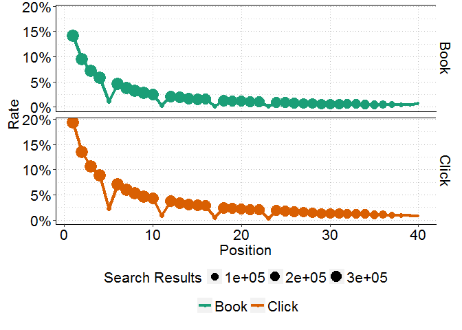

Figure 1: The relationship between search position and clicking and booking rates.

```r
# Function for plotting data
gather_and_plot <- function(data, field) {
    data %>%
        group_by_(field) %>%
        summarise(Click = mean(click_bool),
                  Book = mean(booking_bool),
                  results = n()) %>%
        gather_("key", "value", c("Click", "Book")) %>%
        ggplot(aes_string(x = field, y = "value", group = "key")) +
        geom_point(aes(colour = key, size = results)) +
        geom_line(aes(colour = key), size = 1.5) +
        facet_grid(key ~ .) +
        scale_y_continuous(labels = scales::percent) +
        scale_colour_brewer(palette = "Dark2") +
        guides(colour = guide_legend(title = ""),
               size = guide_legend(title = "Search Results")) +
        xlab(field %>% toproper) +
        ylab("Rate") +
        theme_jim
}
# Make the plot for position
gather_and_plot(data, "position")
```

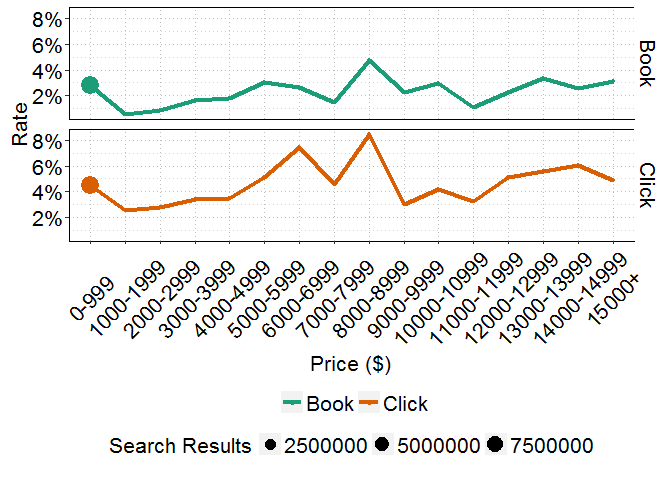

Figure 2: The relationship between price and clicking and booking rates.

```r
# Make the plot for price
gather_and_plot(data, "price_bin") + xlab("Price ($)") +
    theme(axis.text.x = element_text(angle = 45, vjust = 0.5))
```

Figures 1 and 2 show that there is a general decreasing trend when considering booking and clicking rates in relation to search position, and very little trend when considering the effect of price.

Price does not have a large effect, with fluctuations in booking and clicking rates across all prices. However the vast number of search results are for lower-priced options, which may be disguising the overall trend.

# 3 Correlations

In order to quantify these differences further, we assessed the correlations between position, price, and clicking/booking rates. These correlations are displayed in table one.

```r
# Simple correlations between fields
cors <- cor(data %>% select(position, price_usd, click_bool, booking_bool))

# Make the names prettier
rownames(cors) <- gsub("_usd|_bool|", "", rownames(cors)) %>% toproper()
colnames(cors) <- gsub("_usd|_bool|", "", colnames(cors)) %>% toproper()

kable(cors, digits = 3, caption = "Table 1: Correlations between position, price, and booking/click rates")
```

Table 1: Correlations between position, price, and booking/click rates

|  | Position | Price | Click | Booking |
| --- | --- | --- | --- | --- |
| Position | 1.000 | -0.002 | -0.165 | -0.148 |
| Price | -0.002 | 1.000 | 0.000 | 0.000 |
| Click | -0.165 | 0.000 | 1.000 | 0.783 |
| Booking | -0.148 | 0.000 | 0.783 | 1.000 |

It is the case that position is negatively correlated with clicking and booking rates (as expected from the exploratory visualisations) whereas there appears to be no correlation between price and either booking or clicking rates.

# 4 Response model

```r
data <- data %>%
        mutate(response = ifelse(click_bool == 1 | booking_bool == 1, 1, 0))

simple_fit <- glm(response ~ position + price_usd + prop_starrating + srch_length_of_stay + prop_brand_bool + prop_review_score + prop_location_score1,
                 data = data, family = "binomial")

simple_fit %>%
    tidy() %>%
    select(-statistic) %>%
    kable(col.names = c("Term", "Estimate", "Std. Error", "p-Value"),
          digits = 4,
          caption = "Table 2: Model coefficients for the effect of position and price on consumer response")
```

Table 2: Model coefficients for the effect of position and price on consumer response

| Term | Estimate | Std. Error | p-Value |
| --- | --- | --- | --- |
| (Intercept) | -2.2072 | 0.7126 | 0.0020 |
| position | -0.0908 | 0.0169 | 0.0000 |
| price_usd | -0.0057 | 0.0022 | 0.0104 |
| prop_starrating | 0.2380 | 0.1704 | 0.1624 |
| srch_length_of_stay | 0.0520 | 0.0869 | 0.5500 |
| prop_brand_bool | -0.0032 | 0.2921 | 0.9912 |
| prop_review_score | 0.0311 | 0.1533 | 0.8395 |
| prop_location_score1 | -0.0048 | 0.0992 | 0.9612 |

It is seen that position has a statistically significant effect on the log-odds (and therefore the likelihood) of a consumer responding. The effect of price is an order of magnitude smaller than for position, although it is statistically significant when predicting the likelihood of a response.

The effect of position is to change the log-odds of a response by -0.0908 for each increase in position (i.e. for each place *lower* in the results that the hotel was). Price has a much smaller effect, changing the log-odds of response by only -0.0057

# 5 Conclusion

The results of these analyses show that the search position *does* have an effect on customer response - a lower search position significantly reduces the likelihood that a customer will respond. Price has a statistically significant effect, but one that is an order of magnitude smaller than for position, indicating that it has a much smaller influence than position when other factors (e.g. hotel location, quality etc) are controlled for.